# Power analysis

PCB 6455 / BSC 4933: Biometry | Lecture 14

Dr. Brian Maitner

## Today’s agenda

- A real design problem: monitoring a declining bird
- What power is
- Simulating a monitoring program
- **You choose the design**
- What actually drives power

Type and run on a code block: type it into your script and run it. You will need it later. Code without the label is there to watch.

## The problem

## Meet the Northern Bobwhite

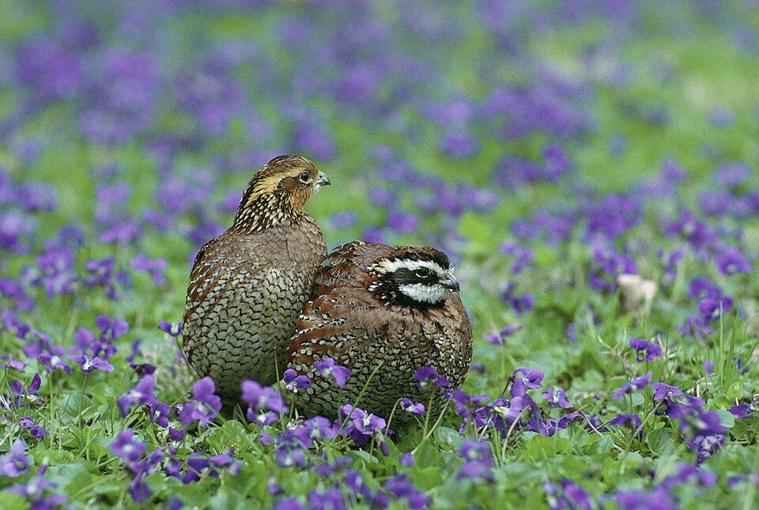

*Colinus virginianus*  
Photo: USFWS, public domain

- A ground-nesting quail of **pine savanna, old fields and field edges**
- Lives in coveys in fall and winter, eats seeds and insects, named for its whistled call
- One of the **most hunted game birds** in the southeast
- Needs open, frequently burned understory

. . .

Fire suppression, denser pine plantations and intensive agriculture have taken most of that habitat away.

## Northern Bobwhite are disappearing

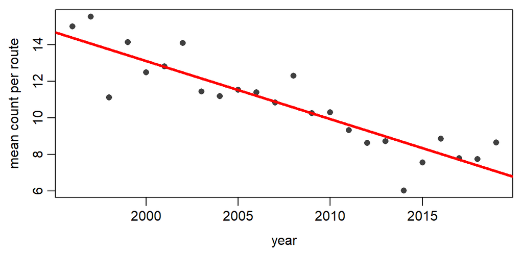

Florida Breeding Bird Survey, 1996 to 2019: about **3% fewer each year**.

## Your job

A state agency wants to monitor bobwhite on managed land.

They can fund about **400 route-visits** in total.

**How should they spend them?**

- Many routes for a few years?
- Few routes for many years?
- Something in between?

You will choose, and then we will find out who was right.

## What is power?

## Four outcomes

|  | $H_0$ is true | $H_0$ is false |
| --- | --- | --- |
| **Reject $H_0$** | false positive, $\alpha$ | correct, **power** |
| **Do not reject** | correct, $1 - \alpha$ | miss, $\beta$ |

**Power = the probability of detecting an effect that is really there.**

Here: the chance the monitoring program finds the decline, given that bobwhite really are declining.

## The world where nothing is happening

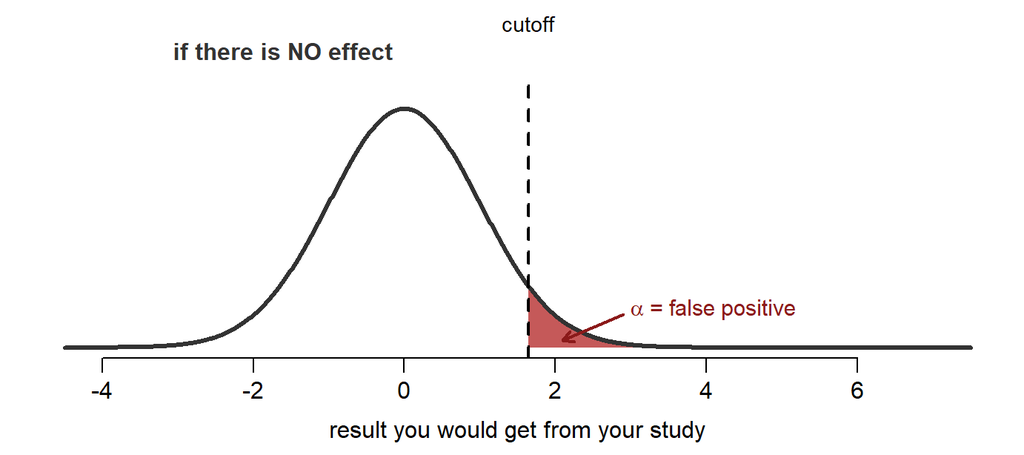

Set the cutoff so that only **5%** of no-effect studies land beyond it. That 5% is $\alpha$, and it is the only thing most papers control.

## Now add the world where something is

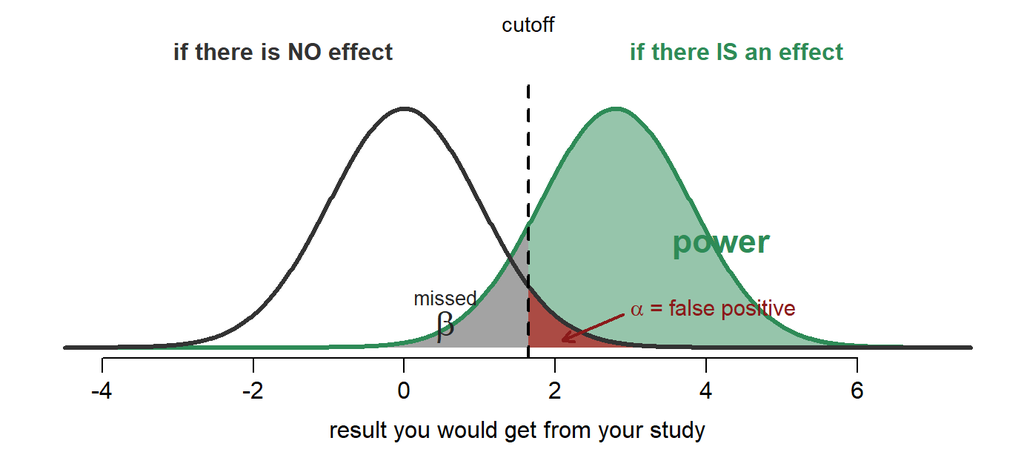

Same cutoff. **Power** is the green area: the chance a real effect lands beyond it. $\beta$ is the grey part you miss.

## Power in a broader sense

Rather than fixating on p-values, ask:

- How does the **amount** of data change my answer?
- How does the **quality** of the data change my answer?
- How do I trade cost against what I can learn?

Other things worth simulating: **bias**, **precision**, **confidence interval width**, **coverage**.

## Building the simulation

## Three things to decide

To simulate a monitoring program we have to say:

1. **How does the population change over time?** The deterministic part.
2. **How do counts vary around that?** The distribution.
3. **What numbers go in?** The parameters.

None of this is guesswork. The BBS data can answer all three.

## Get set up

```r
bbs <- read.csv("https://github.com/bmaitner/biometry_course/raw/refs/heads/main/data/BBS/FL_BBS.csv")

bobwhite <- bbs[bbs$Scientific_Name == "Colinus virginianus", ]

nrow(bobwhite)      # should be 1360 route-years

head(bobwhite[, c("Year", "Route", "total_sightings")])
```

## 1. What shape is a decline?

**Linear: lose the same number**

$$\mu_t = \mu_0 - c\,t$$

Reasonable if the loss is driven by something outside the population: a fixed area of habitat cleared each year.

Reaches zero, then goes negative.

**Exponential: lose the same fraction**

$$\mu_t = \mu_0\,(1 - d)^{\,t}$$

Reasonable if births and deaths scale with how many birds there are, which is how populations usually work.

Approaches zero, never crosses it.

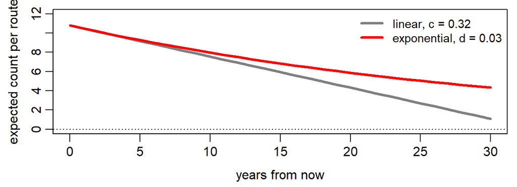

## Which shape does the data support?

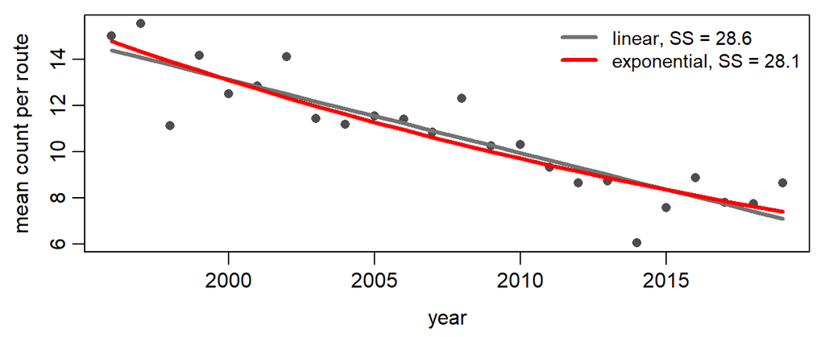

Over 24 years, the data **cannot tell them apart**.

So choose on what they do **outside** the data: the linear model hits zero in 2041. We are extrapolating 20 years, so the choice matters.

## 2. What distribution for the counts?

Counts of birds on a route: whole numbers, no ceiling, and **clumped**, because habitat varies from route to route.

| Candidate | Why not |
| --- | --- |
| Normal | counts are whole numbers and cannot be negative |
| Poisson | requires variance = mean |
| **Negative binomial** | counts, no ceiling, variance can exceed the mean |

Normal is out on sight. **Poisson makes a claim we can test.**

## Testing the Poisson claim

```r
counts_real <- bobwhite$total_sightings

mean(counts_real)
var(counts_real)

mean(counts_real >= 40)                            # observed

ppois(39, lambda = mean(counts_real), lower.tail = FALSE)   # Poisson says
```

|  | observed | Poisson says |
| --- | --- | --- |
| variance | 111 | 11 |
| P(count $\geq$ 40) | 0.024 | 0.000000000007 |

A Poisson is **fixed once you know the mean**: its variance *is* the mean, and `ppois()` needs nothing else. That is why it has no way to match these data. The negative binomial has a second parameter, so it has a chance.

## 3. The parameters come from the data

```r
mu0 <- mean(bobwhite$total_sightings)
v <- var(bobwhite$total_sightings)

size <- mu0^2 / (v - mu0)

round(c(mean = mu0, variance = v, size = size), 2)
```

```
    mean variance     size
   10.78   111.44     1.15
```

```r
mu0 + mu0^2 / size          # the variance this negative binomial implies
```

```
[1] 111.4434
```

| Parameter | Value | Where it came from |
| --- | --- | --- |
| $\mu_0$, starting mean | 10.8 | the data |
| $k$, clumping | 1.15 | the data, by matching the variance |
| $d$, annual decline | 0.03 | the published trend, **the effect we want to detect** |

## Does the negative binomial pass the same test?

The variance matches, but we **made** it match. Try something we did not fit:

```r
pnbinom(39, mu = mu0, size = size, lower.tail = FALSE)
```

|  | observed | Poisson said | Negative binomial says |
| --- | --- | --- | --- |
| variance | 111 | 11 | 111, by construction |
| P(count $\geq$ 40) | 0.024 | 0.000000000007 | 0.023 |

Nothing in the fitting used the tail. **That** is a real test, and it passes.

## The model, in one place

**Math**

Expected count in year $t$:

$$\mu_t = \mu_0\,(1 - d)^{\,t}$$

Counts around it:

$$y_t \sim \text{NegBinomial}(\mu_t,\; k)$$

with $\mu_0 = 10.8$, $d = 0.03$, $k = 1.15$.

**R**

```r
mu <- mu0 * (1 - d)^year

counts <- rnbinom(n = length(year),
                  mu = mu,
                  size = k)
```

**How we will analyze it**

```r
lm(log(counts + 1) ~ year)
```

## What we are actually choosing

The model is settled. What is **not** settled is the survey itself.

**Fixed:** the budget

$$\text{routes} \times \text{years} = 400$$

One route surveyed in one year is one visit, and the agency can pay for 400 of them.

**Yours to choose:** the allocation

- Many routes, few years? **Space**
- Few routes, many years? **Time**

The model says what the birds do. The **design** says where and when you look.

## Step 1: the expected counts

```r
mu0 <- 10.8
k <- 1.15
d <- 0.03

n_routes <- 40
n_years <- 10

year <- rep(0:(n_years - 1), each = n_routes)

mu <- mu0 * (1 - d)^year

plot(year, mu, ylim = c(0, 12))
```

400 route-visits: 40 routes, each surveyed for 10 years. No randomness yet.

## Step 2: add the noise

```r
counts <- rnbinom(n = length(year), mu = mu, size = k)

plot(jitter(year), counts)
points(year, mu, col = "red", pch = 16)
```

That is **one monitoring program**: 400 counts, and the truth in red.

## Step 3: analyze it like real data

```r
m <- lm(log(counts + 1) ~ year)

summary(m)$coefficients["year", ]
```

Two things to read:

- Is the **slope** negative, as it should be?
- Is **`Pr(>|t|)`** below 0.05?

## Four programs, four answers

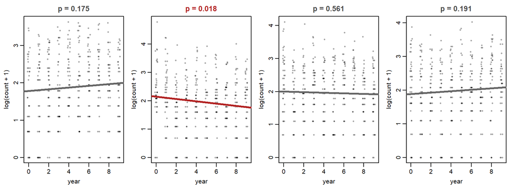

Same truth, same design, four runs. **One detected it. Two slope the wrong way.**

## One study is not enough

Power is the **proportion** of programs that find the decline. So run many:

```r
nsim <- 500
found <- numeric(nsim)

for (i in 1:nsim) {

  counts <- rnbinom(n = length(year), mu = mu, size = k)
  m <- lm(log(counts + 1) ~ year)

  found[i] <- summary(m)$coefficients["year", "Pr(>|t|)"] < 0.05

}

mean(found)      # this is the power
```

## Reading the output

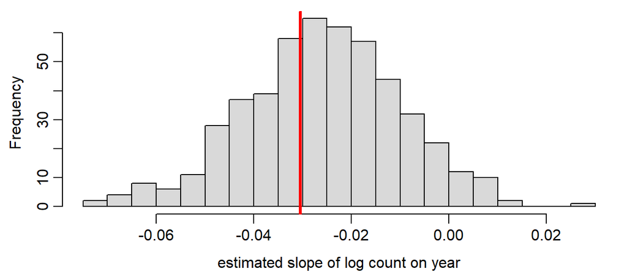

500 programs. True slope in red. **About a third** landed far enough from zero to be called significant.

## Your turn: compute the power of one design

```r
year <- rep(0:9, each = 40)       # 40 routes, 10 years
mu <- 10.8 * (1 - 0.03)^year

found <- numeric(500)

for (i in 1:500) {
  counts <- rnbinom(n = length(year), mu = mu, size = 1.15)
  m <- lm(log(counts + 1) ~ year)
  found[i] <- summary(m)$coefficients["year", "Pr(>|t|)"] < 0.05
}

mean(found)
```

400 route-visits. **Would you fund this program?**

## The decision

## Same budget, four designs

All cost **400 route-visits**. Which would you fund?

|  | Routes | Years |
| --- | --- | --- |
| **A** | 200 | 2 |
| **B** | 80 | 5 |
| **C** | 40 | 10 |
| **D** | 20 | 20 |

**Commit to one before we run it.** Hands up for each.

## The answer

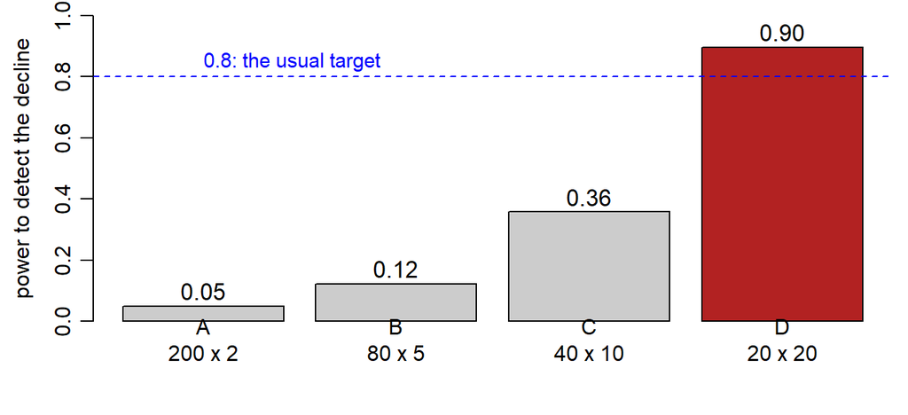

Same cost. **5% against 90%.**

## Why years beat routes

A trend is a **slope over time**. Slopes are estimated from the **spread of the x values**.

- Adding **years** stretches the x axis: 2 years of change against 20 years of change
- Adding **routes** only averages the noise at the years you already have

## How long before you would know?

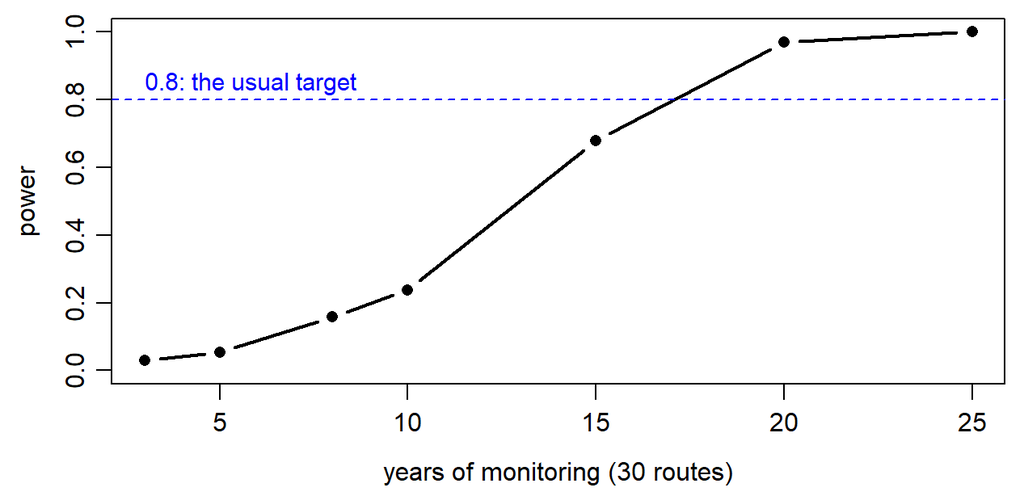

At 30 routes, a 3% decline needs about **18 years** before you would reliably catch it.

## Your turn: what if the decline is worse?

```r
year <- rep(0:9, each = 40)   # 40 routes, 10 years

decline <- 0.03               # try 0.01, 0.05, 0.10

found <- numeric(500)
for (i in 1:500) {
  counts <- rnbinom(length(year), mu = 10.8 * (1 - decline)^year, size = 1.15)
  m <- lm(log(counts + 1) ~ year)
  found[i] <- summary(m)$coefficients["year", "Pr(>|t|)"] < 0.05
}
mean(found)
```

Which is easier to detect, a slow decline or a fast one?

## Three honest warnings

**Power is not a p-value.** It is computed before you have data, from assumptions you chose.

**Post-hoc power is useless.** Computing power from your observed effect after a non-significant result tells you nothing new.

**A significant result from an underpowered study is not reassuring.** When power is low, the effects that do reach significance are the overestimates.

## This is the midterm, Part 3

Same machinery, simpler model:

- intercept 2, slope 1, **standard deviation from 1 to 20**
- at least three sample sizes
- a figure, and a sentence on what it means

Skeleton: `midterm/midterm_b_example.R`

**Due Tuesday Oct 13, 11:59 pm.**

## Now one of your own

## Do protected reefs hold more fish?

NOAA surveys reefs across the Florida Keys, inside and outside protected areas, and records the fish seen on each survey.

```r
reef <- read.csv("https://github.com/bmaitner/biometry_course/raw/refs/heads/main/data/Reef_fish/NCRMP_reef_fish_surveys.csv")

reef$protected <- ifelse(reef$PROT == 0, "no", "yes")

# 8 of the 8560 surveys recorded no fish at all. log(0) is -Inf, which would
# wreck every summary below, so set them aside.
reef <- reef[reef$total_abundance > 0, ]
```

**The question:** a manager wants to know whether protection works. How many surveys per group would it take to find out?

## 1. What is the deterministic part?

For the bobwhite it was a curve through time. Here there is **no time axis**: just two groups with different expected abundance.

So the deterministic part is a pair of means. Your decision:

- Describe the effect as a **difference** (protected minus unprotected), or
- Describe it as a **ratio** (protected divided by unprotected)?

Plot it both ways before you choose:

```r
unprot <- reef$total_abundance[reef$protected == "no"]
prot   <- reef$total_abundance[reef$protected == "yes"]

hist(unprot)                 # raw scale
hist(log(unprot))            # log scale: which looks symmetric?

____                         # now do the same for prot
```

## 2. Which distribution?

Fish per survey is positive, continuous, and right skewed.

| Candidate | Rule it in or out |
| --- | --- |
| Normal | allows negatives, and the data are skewed |
| Poisson | these are not whole numbers, see below |
| Lognormal or gamma | positive, continuous, right skewed: both plausible |

**“Abundance” sounds like a count. Check before you assume:**

```r
head(sort(unique(reef$total_abundance)))     # 0.0  0.5  1.0  1.5  2.0  2.5
```

Then **check it the way we checked the Poisson**: make it predict something.

```r
mean(unprot > 500)           # observed: how often is a survey this rich?

____(500, meanlog = ____, sdlog = ____, lower.tail = FALSE)
#  ^ the p-function for your chosen distribution
```

## 3. The parameters

Estimate these from the data yourselves, on the scale your distribution works on:

```r
meanlog_unprot <- ____(log(unprot))     # centre, on the log scale
sdlog_unprot   <- ____(log(unprot))     # spread, on the log scale

meanlog_prot <- ____
sdlog_prot   <- ____
```

Two questions worth asking of your answers:

- Is the **spread** similar in the two groups? Does that simplify the simulation?
- What **ratio** do the two centres imply?

## 4. What are you choosing?

**Fixed:** survey effort. Say the agency can fund **120 surveys** in total.

**Yours to choose:**

- How many go in each group
- Which effect size you want to be able to detect

```r
n_per_group <- 60        # 120 surveys, split evenly. Your call.
effect <- 1.5            # the ratio you want to be able to detect. Also your call.
```

The second one is not in the data. **You have to decide what difference would matter** before power means anything.

## 5. Simulate, analyze, repeat

```r
# one study: draw each group from your distribution
sim_unprot <- ____(n_per_group, meanlog = meanlog_unprot, sdlog = sdlog_unprot)

# adding log(effect) on the log scale multiplies by effect on the fish scale
sim_prot   <- ____(n_per_group, meanlog = meanlog_unprot + log(effect),
                   sdlog = sdlog_unprot)

# analyze it the way you would analyze the real surveys
____                                      # compare the two groups, get a p-value

# many studies
found <- numeric(500)
for (i in 1:500) {
  ____                                    # the two draws again
  found[i] <- ____ < 0.05                 # did this study find the difference?
}
mean(found)                               # the power
```

Why **add** when the effect is a ratio? Because $e^{\,m + \log 1.5} = 1.5\,e^{\,m}$: a shift on the log scale is a multiplication on the original scale.

Then vary `n_per_group`, and find where power reaches **0.8**.

## If something breaks

Three things that trip people up here:

- **`-Inf` or `NaN` in your summaries.** Something got logged that should not have been, or a zero slipped through.
- **Simulated numbers in the millions.** `rlnorm()` wants the mean and sd *of the logs*, not of the raw abundances. Check that your `meanlog` is around 5, not around 150.
- **Power of 1.00 at every sample size.** Your two groups are probably further apart than you meant. Print the ratio you are simulating.

## Check yourself

Distribution: **lognormal** works well here, gamma is defensible. What the real data say:

|  | unprotected | protected |
| --- | --- | --- |
| median fish per survey | 139 | 171 |
| sd of log abundance | 0.90 | 0.91 |

Power to detect a **50% difference**: about 0.27 at n = 20, 0.69 at n = 60, 0.88 at n = 100

Power to detect the **23% difference actually observed**: about 0.23 at n = 60, and still only 0.65 at n = 200

## Additional practice

On your own, extend the bobwhite simulation:

- What if routes differ in quality, some good and some poor?
- What if you survey each route twice a year?
- What if the agency can afford 800 visits?

## Before next class

**Assignment 2** is due Friday Oct 9, 11:59 pm

Read Bolker **6.1 to 6.2** (6.2.2 is optional)

Next time: **likelihood**, and the midterm is due